# Politik

Kevin

7/26/2021

was wäre cool zu visualisieren? wie sich das im laufe der zeit verändert hat? mit den bundestagen an sich? verteilung dann von männern und frauen zeigen

verteilung innerhalb der parteien zeigen und wie sich diese im laufe der zeit verändert haben.

größe der parteien??

# Infotext

Statista. geschlechtliche Ungerechtigkeit in der Bundestagszusammensetzung etc. googlen nach allgemeinem Meinungsbild zu Männer und Frauen Verteilung in der Politik

# seats in parliament

vielleicht karte zeigen mit allen ländern

Hintergrundinfos: Proportion of seats held by women in national parliaments (%)(SG.GEN.PARL.ZS) Definition: Women in parliaments are the percentage of parliamentary seats in a single or lower chamber held by women. Quelle: Inter-Parliamentary Union (IPU) (www.ipu.org). For the year of 1998, the data is as of August 10, 1998. aggregation method: Weighted average

meine Quelle: https://databank.worldbank.org/source/gender-statistics

könnte auch mit Bildung zusammenhängen, dass für Frauen nicht dieselben Voraussetzungen gelten wie für Männer

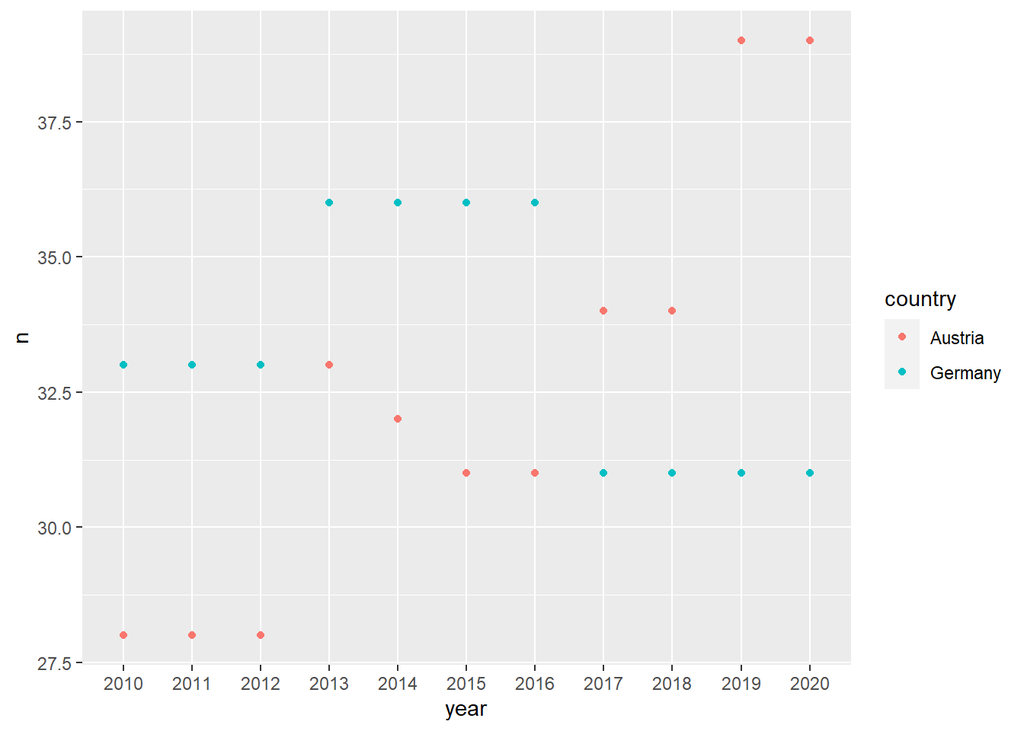

```r
before_clean_seats <- read.csv("data/raw/before_clean_seats_parliaments.csv", check.names = F)

library(dplyr)

seats <- before_clean_seats %>%
            filter(country != "") %>%
            pivot_longer(cols = -country, names_to = "year", values_to = "n") %>%
            mutate_if(is.numeric, round)


###

seats %>% view()

seats %>%
  filter(country %in% c("Germany", "Austria")) %>%
  filter(year %in% 2010:2020) %>%
  ggplot() +
  aes(x = year,
      y = n,
      color = country) +
  geom_point()
```

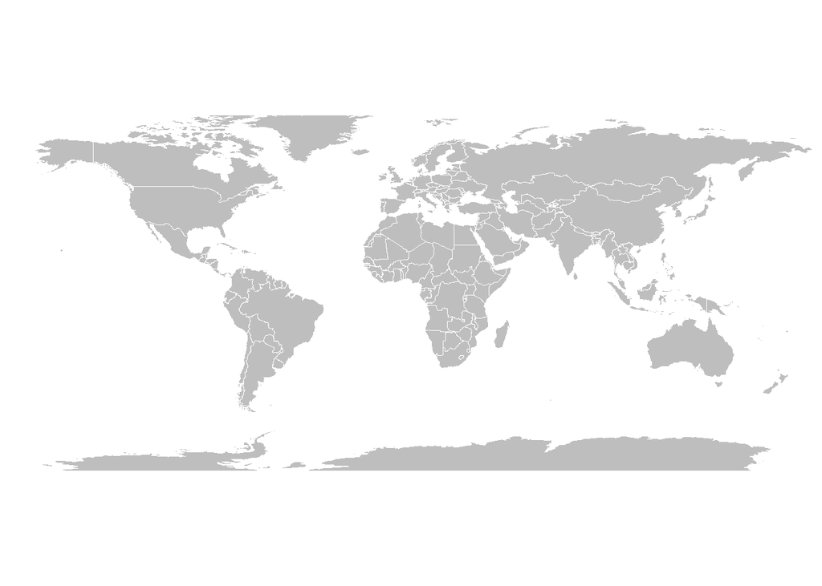

```r
library(maps)
# Check all available geospatial objects:
# help(package='maps')

# Map of the world:
map('world',col="grey", fill=TRUE, bg="white", lwd=0.05, mar=rep(0,4),border=0, ylim=c(-80,80) )
```

```r
map_data("world") %>% view()
```